# Setting up VS code to run python

Andrew Alverson and John Tipton

Created: 9/20/2020 Last modified: 9/20/2020

When setting up your computer to run python code, a common issue is that most computers have multiple versions of python installed. First, you need to choose your python version in VS code. To choose the version of python in VS code, first create a new file using the menu bar *file* $\Rightarrow$ *new file* and then save the file ending with `.py` (e.g., `first-file.py`).

[figure not shown]

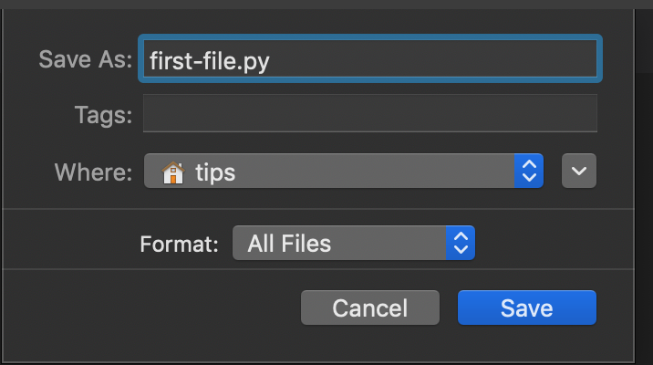

If this is your first time opening a python file, VS code will ask if you want to install recommended python modules, say yes to this. Once the recommended python modules are installed, you will get a popup asking to choose your python version. Click on this popup.

[figure not shown]

Make sure you choose a python version 3.X.X. On your computer, you should expect to see a different version of python than what is shown here.

[figure not shown]

Choose a version of python (version 3.X.X) and write down the path to that version of python. For my computer, my python path that I chose is `/Users/tips/Library/r-miniconda/bin/python`. Again, the path for your python version will be different. The path will be referenced as `<path-to-python>`.

Next, we need to set the system python version. This can be tricky so make sure you follow the instructions.

## 0.1 Setting the python alias on Mac

I am assuming you are working on MacOs Mojave (10.14.6). Open a terminal on your computer and type

```bash
which python
python --version
```

If the output of `python --version` displays the python version chosen in VS code, you likely have the same python version aliased for both VS code and your system. Most likely, the output of `python --version` will not be the same as your chosed interpreter in VS code. In that case you can enter in the terminal

```bash
echo "alias python=<path-to-python>" >> ~/.zshrc
```

where `<path-to-python>` is the path from the VS code interpreter choice. For my computer, this command is

```bash
echo "alias python=/Users/tips/Library/r-miniconda/bin/python" >> ~/.zshrc
```

To make sure the system recognizes the change, in terminal type

```bash
cat ~/.zshrc
```

and see if the output includes the line `python=<path-to-python>`. If the file doesn’t include this line, run the line `echo "alias python=<path-to-python>" >> ~/.zshrc` again. Then, in terminal type

```bash
source ~/.zshrc
```

to update the system path variable and then check the python version with

```bash
python --version
```

Now the python version should be the same as your chosen interpreter from VS Code

- More details and motivation for this is [available here](https://opensource.com/article/19/5/python-3-default-mac)

## 0.2 Microsoft Windows

**Note: This HAS NOT BEEN TESTED**

- The stackoverflow post here is a good resource

Check your python version by opening the console and typing

```
py
```

You can get the current path to python3 using

```
echo %PY_PYTHON3
```

You can [read the tutorial here about setting Path variables](http://www.dowdandassociates.com/blog/content/howto-set-an-environment-variable-in-windows-command-line-and-registry/), particularly the part about the use of the `setx` command. We want to modify the python3 path variable stored as `PY_PYTHON3` using the command

```
setx PY_PYTHON3 "<path-to-python>"
```

Then, close your console window and start a new console window. Check the python path using

```
echo %PY_PYTHON3
```

This should now be the same as the interpreter you chose of VS code.